# STAA575: Homework 2

Jeremy Primus

1/27/2018

## Metropolis-Hastings Algorithm

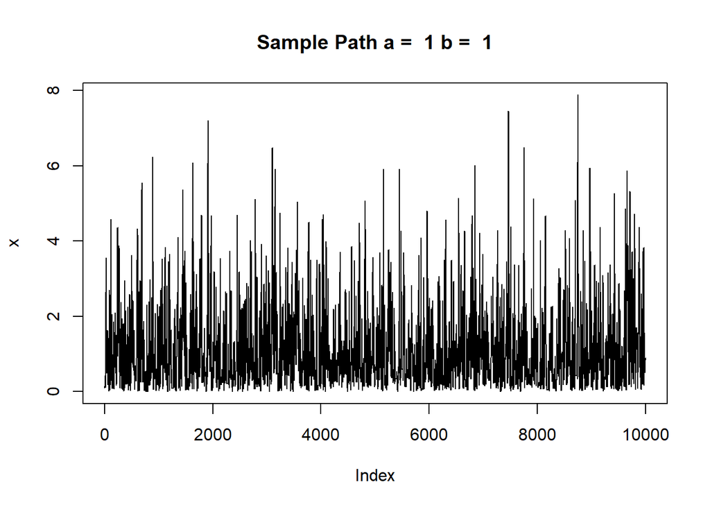

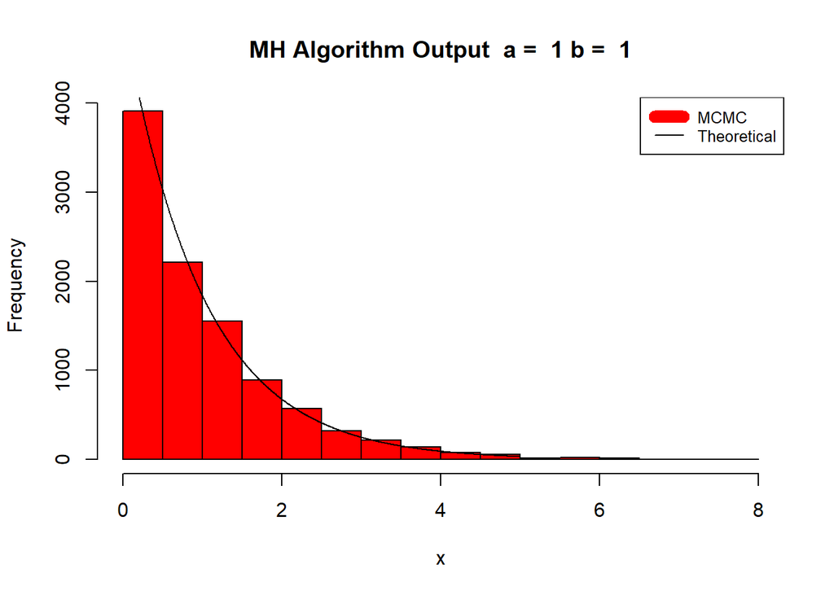

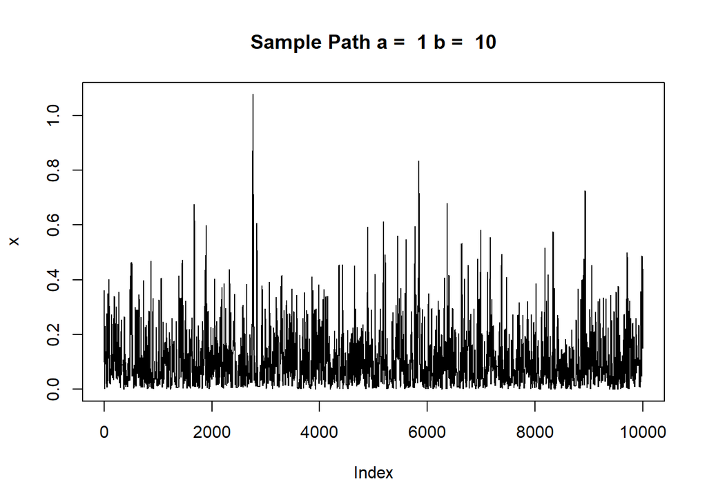

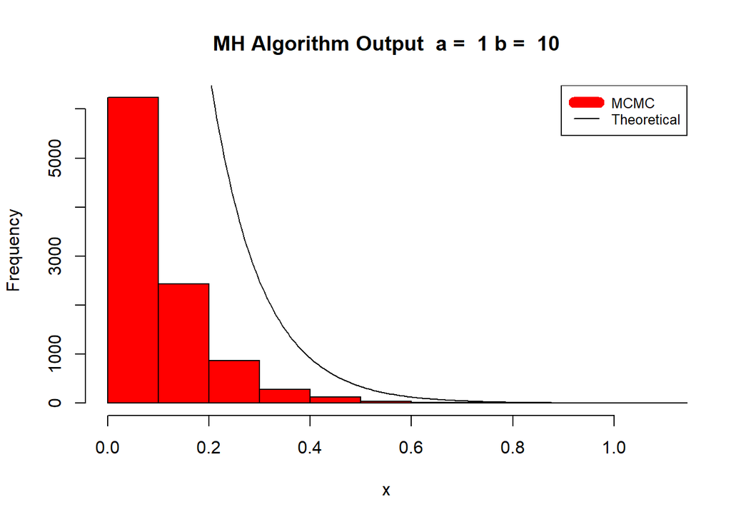

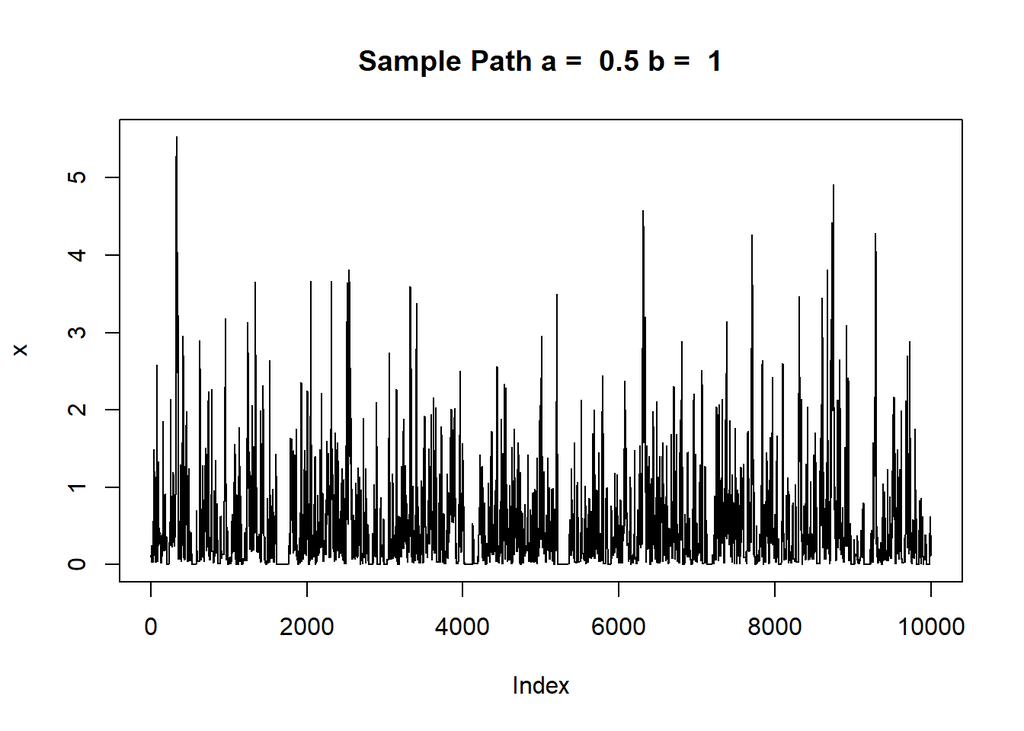

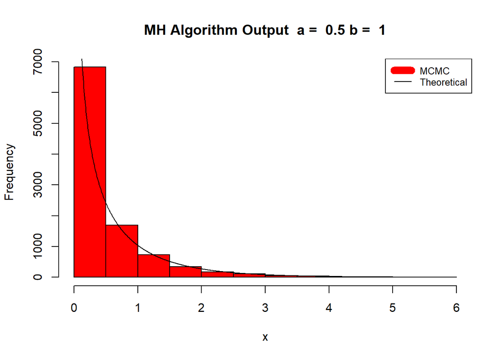

```r
library(knitr)
rm(list = ls())          # clear variables

# initialize vectors for final table
acceptanceRate <- c(0,0,0)
target <- letters[1:3]
proposal <- letters[1:3]
theoreticalMean <- c(0,0,0)
obsMean <- c(0,0,0)
theoreticalStdDev <- c(0,0,0)
obsStdDev <- c(0,0,0)

for (ii in c(1,2,3)){           # loop to run for three sets of model parameters
  # model parameters
  iter <- 10000                 # set number of iterations
  a <- c(1, 1, 0.5)             # set parameters of the target distribution
  b <- c(1, 10, 1)
  x <- rep(0.5,iter)            # initialize a vector for target distribution
  x[1] <- 0.1                   # draw first value from target
  stdDev <- c(2, 0.2, 0.7)      # set standard deviation for proposal


  #MHAlgorithm
  for(t in seq(1, iter, length=iter)){
    xstar <- rnorm(1, x[t], stdDev[ii])         # draw x* from proposal
    mHRatio <- dgamma(xstar, a[ii], rate=b[ii])*dnorm(x[t], xstar, stdDev[ii])/(dgamma(x[t], a[ii],   rate=b[ii])*dnorm(xstar, x[t], stdDev[ii]))     # evaluate mHRatio
    if (mHRatio >= 1){        # accept criteria 1
      x[t+1] <- xstar
    } else {
      u <- runif(1, 0, 1)     # Bernoulli draw
      if (u < mHRatio){       # accept criteria 2
        x[t+1] <- xstar
      } else {                # reject criteria
          x[t+1] <-x[t]
      }
    }
  }
  # generate plots
  plot(x, type = 'n', main= paste("Sample Path a = ", a[ii], 'b = ', b[ii]))
  lines(x)

  hist(x, col = "red", main = paste('MH Algorithm Output  a = ', a[ii], 'b = ', b[ii]))
  xx <- seq(0, 5, length = 1000)
  y <- (iter/2)*dgamma(xx, a[ii], rate = b[ii])
  lines(xx,y)
  legend("topright", legend=c("MCMC", "Theoretical"),
       col=c("red", "black"), lty=2:1, lwd=c(10,1), cex=0.8)

  # generate data for table
  target[ii] <- paste("Gamma(", a[ii], ",", b[ii],")")
  proposal[ii] <- paste("Normal(x[t]", ",", stdDev[ii],")")
  acceptanceRate[ii] <- length(unique(x))/length(x)
  theoreticalMean[ii] <- a[ii]/b[ii]
  obsMean[ii] <- mean(x[(iter/2):iter])
  theoreticalStdDev[ii] <- a[ii]/b[ii]^2
  obsStdDev[ii] <- sqrt(var(x[(iter/2):iter]))
}
```

```r
# create table
df = data.frame(target, proposal, acceptanceRate, theoreticalMean, obsMean, theoreticalStdDev, obsStdDev)
kable(df)
```

| target | proposal | acceptanceRate | theoreticalMean | obsMean | theoreticalStdDev | obsStdDev |
| --- | --- | --- | --- | --- | --- | --- |
| Gamma( 1 , 1 ) | Normal(x[t] , 2 ) | 0.3420658 | 1.0 | 1.0104190 | 1.00 | 1.0170510 |
| Gamma( 1 , 10 ) | Normal(x[t] , 0.2 ) | 0.3391661 | 0.1 | 0.0982454 | 0.01 | 0.1002165 |
| Gamma( 0.5 , 1 ) | Normal(x[t] , 0.7 ) | 0.3756624 | 0.5 | 0.4838512 | 0.50 | 0.6633162 |

```r
# the above code should ideally be written as a function to allow the user to pass in values, and completely customize the algorithm.  However, I am new to R and have not written any functions yet.  I will apply this improvement if we continue developing our own algorithms for MCMC.
```

## C. Output with x* drawn from proposal with mean 0

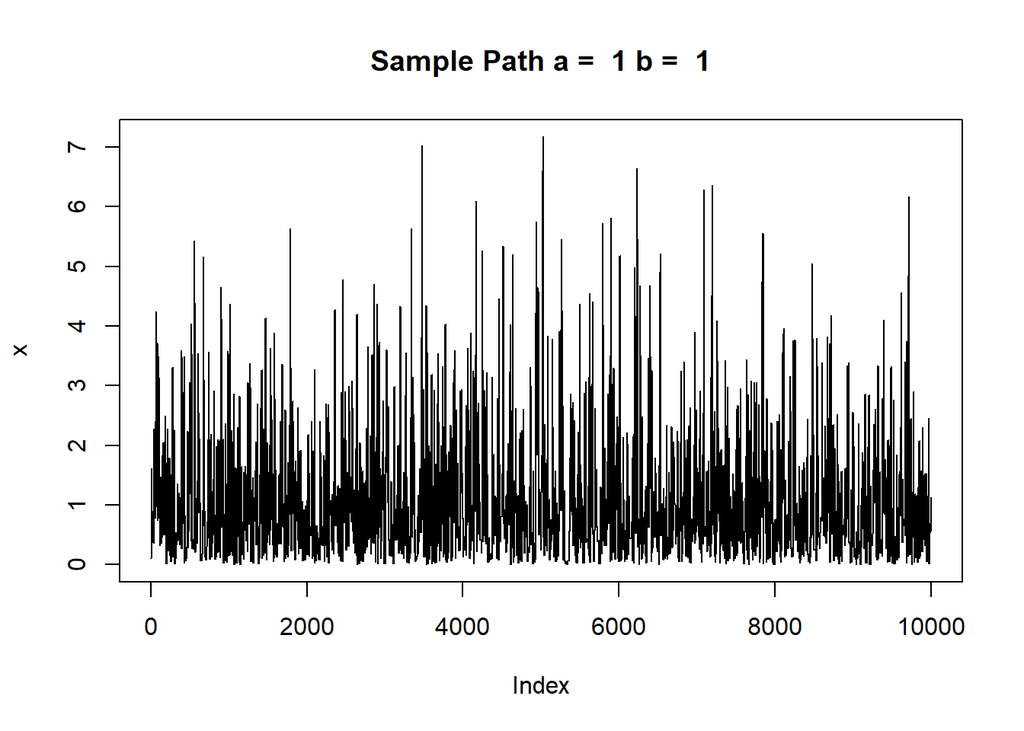

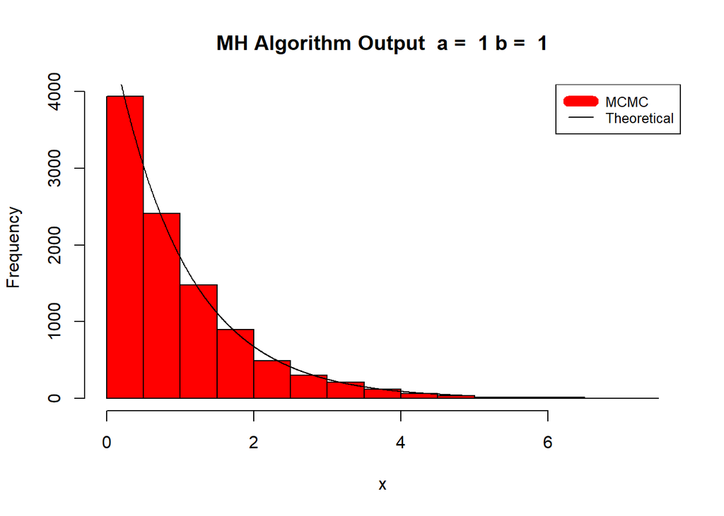

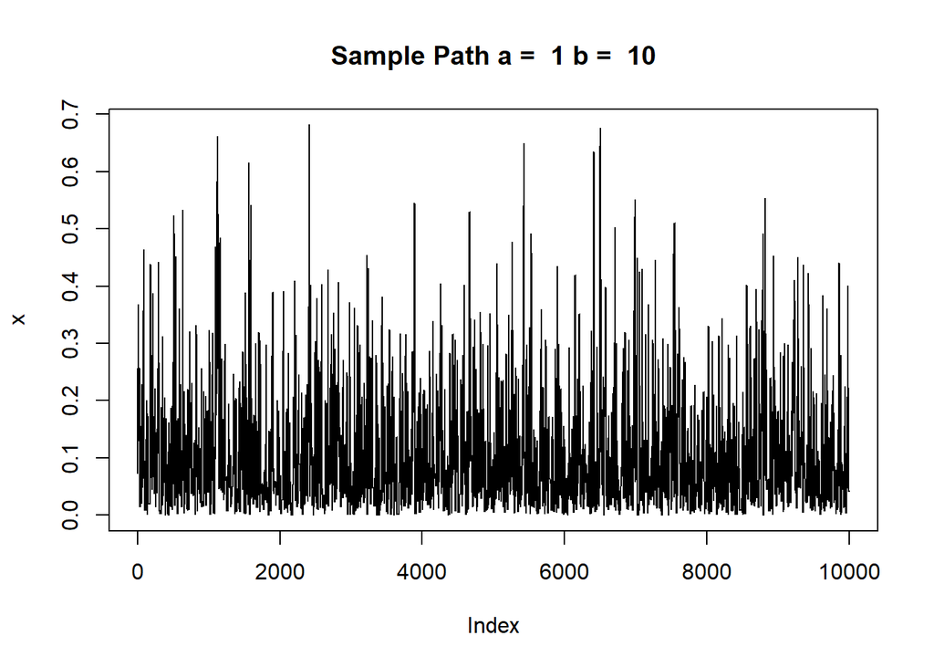

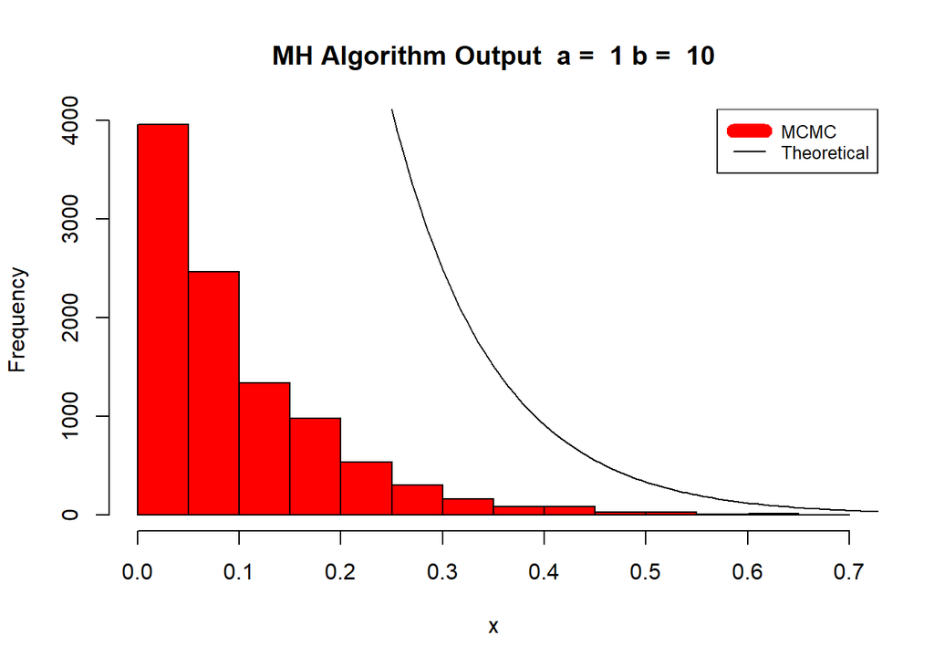

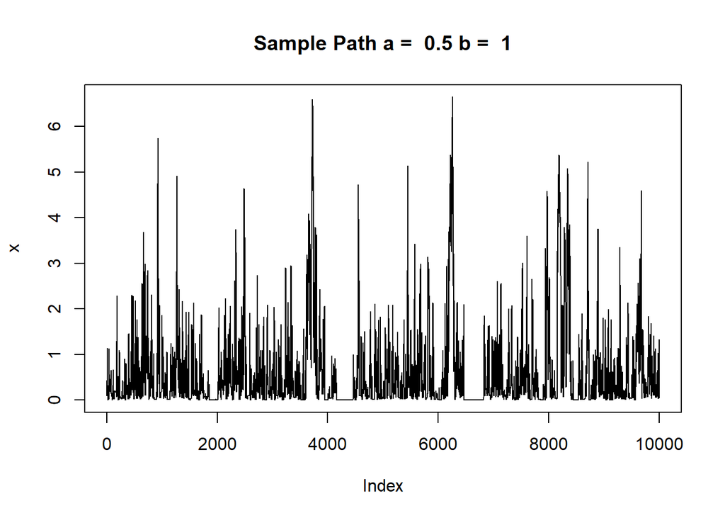

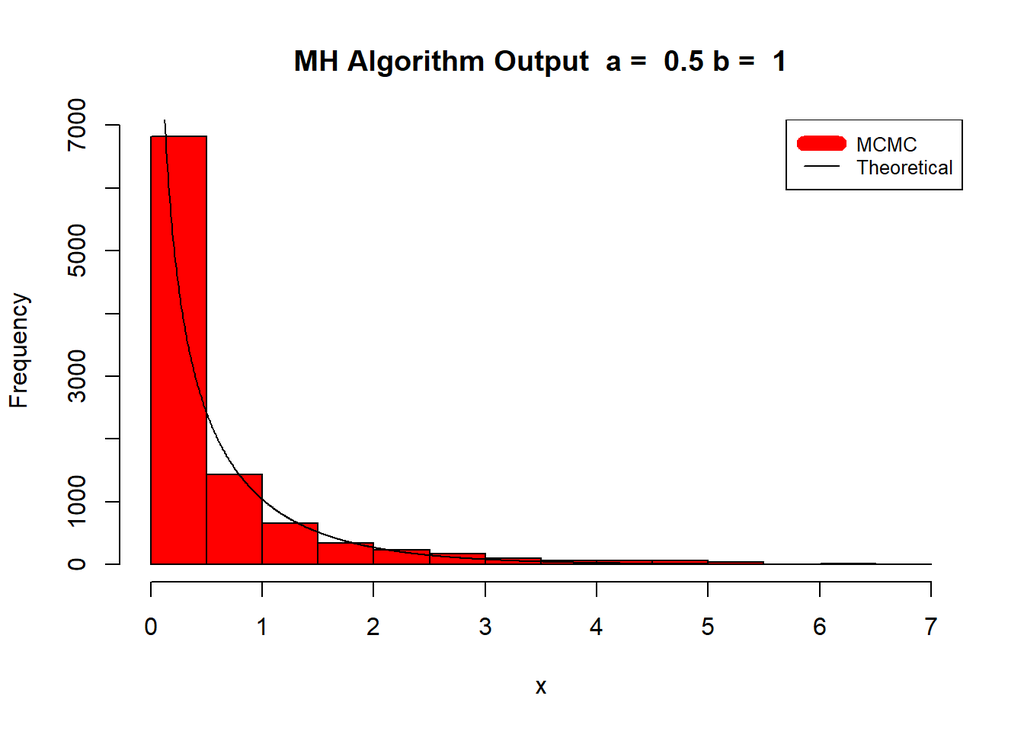

| target | proposal | acceptanceRate | theoreticalMean | obsMean | theoreticalStdDev | obsStdDev |
| --- | --- | --- | --- | --- | --- | --- |
| Gamma( 1 , 1 ) | Normal(0 , 2 ) | 0.3233677 | 1.0 | 0.9587394 | 1.00 | 0.9615970 |
| Gamma( 1 , 10 ) | Normal(0 , 0.2 ) | 0.3351665 | 0.1 | 0.0965749 | 0.01 | 0.0946652 |
| Gamma( 0.5 , 1 ) | Normal(0 , 0.7 ) | 0.3609639 | 0.5 | 0.6285456 | 0.50 | 1.0045767 |

## D. Summary

The Metropolis Hastings algorithm performed especially well for the cases a=1, b=1. The estimated values of the mean and standard deviation closely match the theoretical value, and the real distribution function overlays the historgram well. In fact, for all target parameter sets and the original proposal sampled from an x[t] mean, the algorithm accurately estimated the mean. However, for a=1, b=10, the histogram deviates somewhat significantly from the target density. This error also materializes as a vastly overestimated standard deviation. Likewise, a=0.5, b=1, significantly overestimated the standard deviation. However, the histogram and target PDF are in better agreement.

## 2. Gibbs Sampler

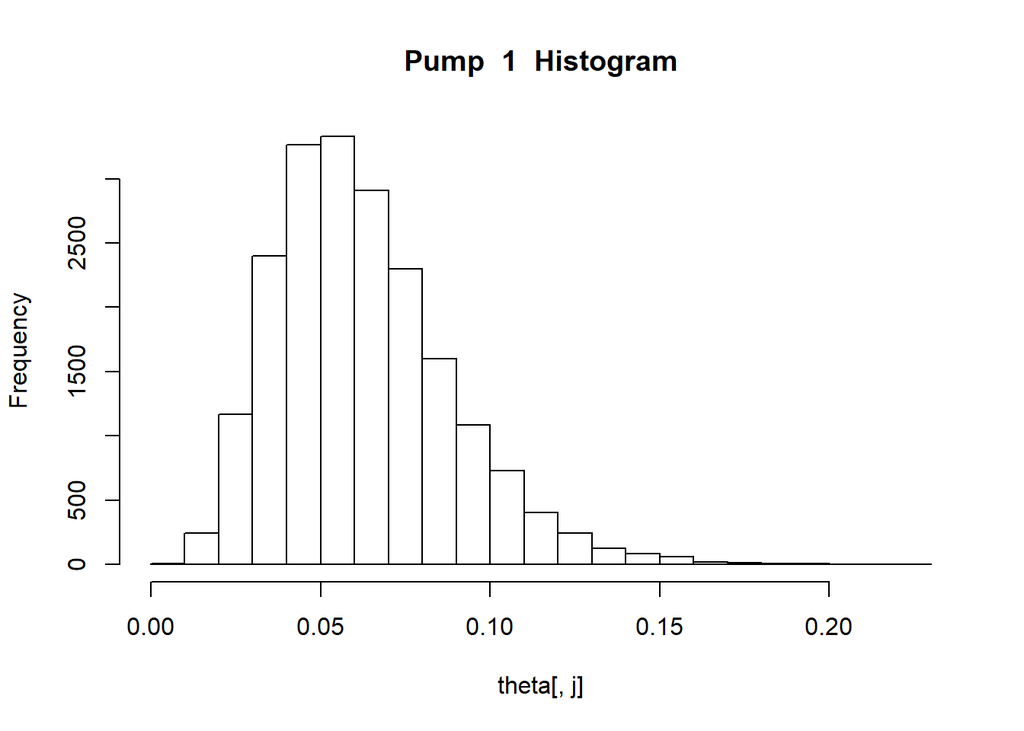

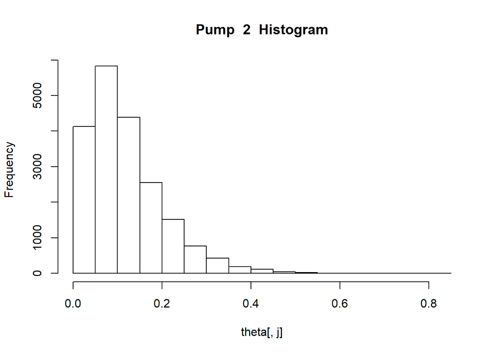

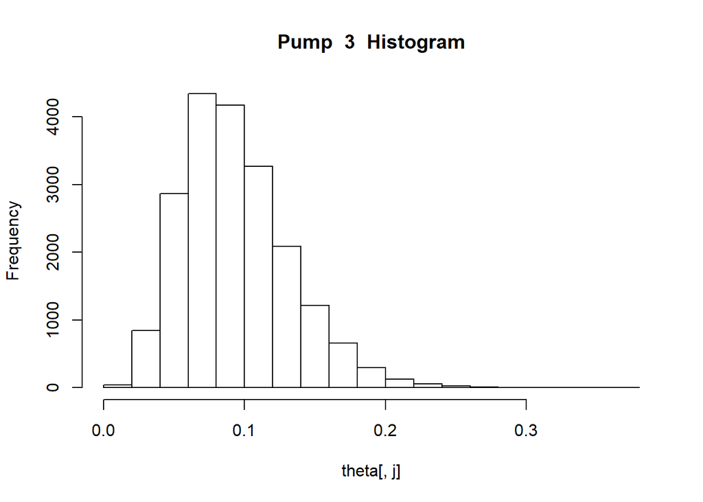

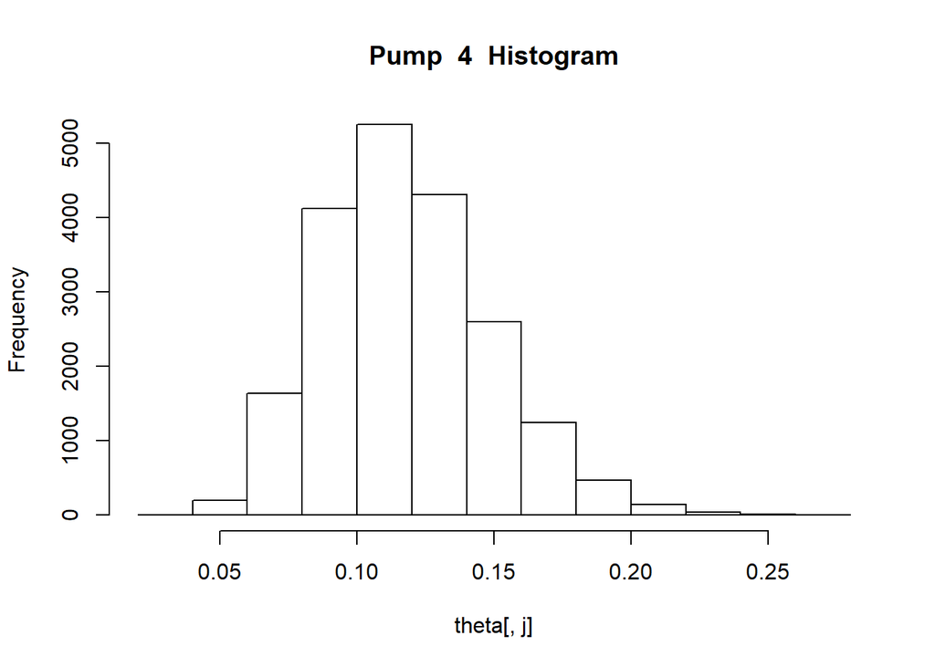

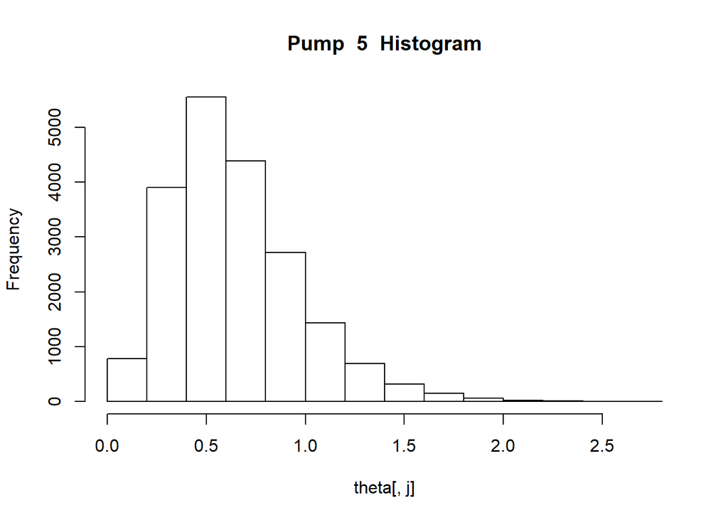

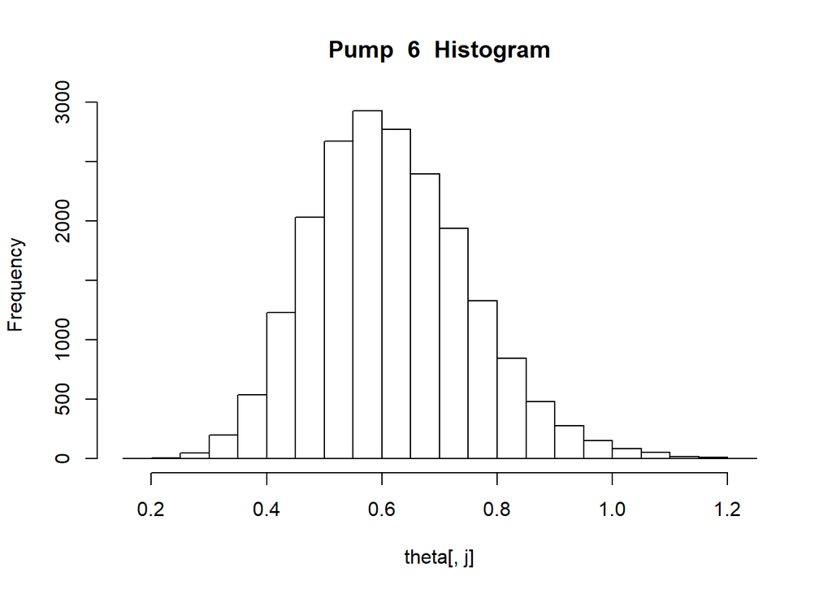

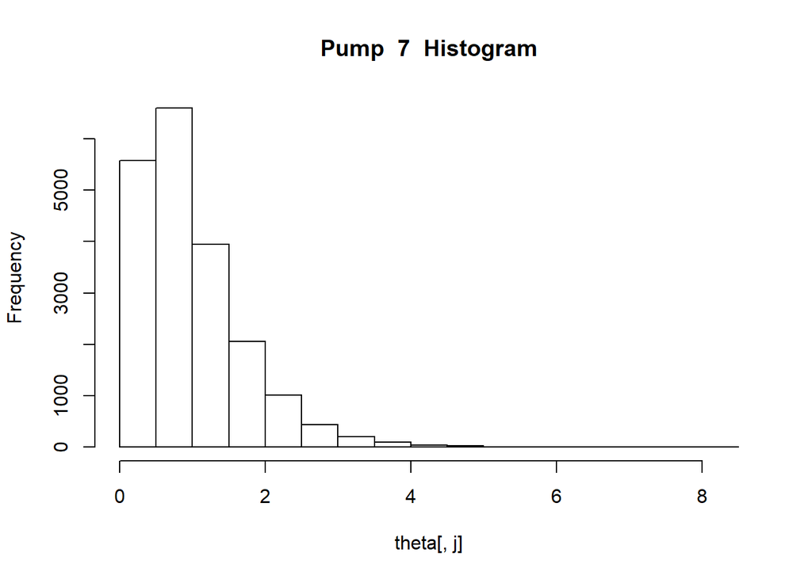

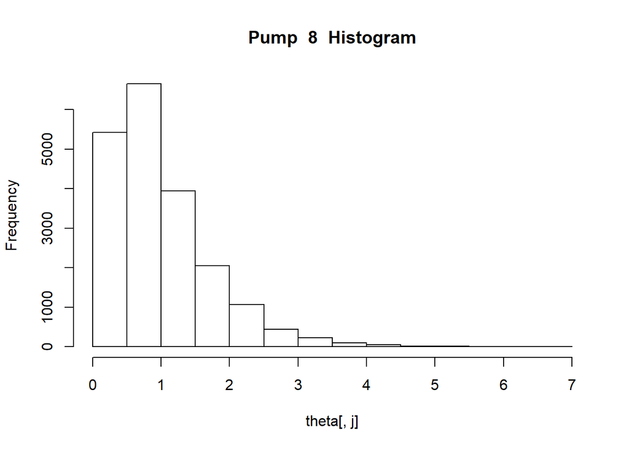

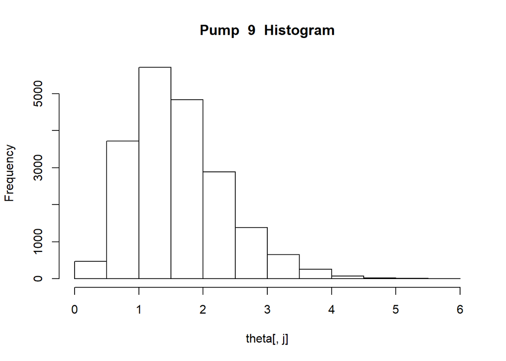

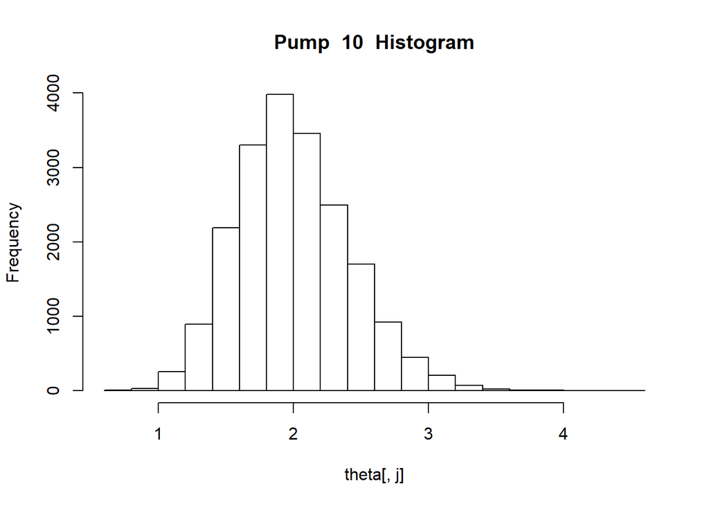

```r
rm(list=ls())           # clear variables
library(coda)

# data collection
tis <- c(94.50, 15.70, 62.90, 126.0, 5.20, 31.40, 1.05, 1.05, 2.10, 10.50)     # durations of data collection
xis <- c(5, 1, 5, 14, 3, 19, 1, 1, 4, 22)     # number of failures
k <- length(xis)                              # number of parameters in the model (ie pumps)

# model parameters
alpha <- 1
c <- 1
d <- 1

iter <- 20000     # number of iterations

# create iterable variables and initialize first values
b <- matrix(1,iter,1)
b[1] <- 2                                    # starting value of beta
theta <- matrix(1,iter,k)
theta[1,] <- xis/tis                         # data: failure rates
predictedMean <- rep(0,k)
compliant <- letters[1:k]

# Gibbs loop
for(t in seq(2, iter, length=iter)){
  b[t] <- rgamma(1, k*alpha+c, rate = sum(theta[t,])+d)
  for(i in seq(1, k, length=k)){
    theta[t,i] <-rgamma(1, xis[i]+alpha, rate = tis[i]+b[t])
  }
}

# identify 95% confidence interval
credibleIntervals <- HPDinterval(mcmc(theta), prob = 0.95)

# figure generation
for(j in seq(1, k, length=k)){
  hist(theta[,j], main = paste('Pump ', j, ' Histogram'))
  predictedMean[j] <- mean(theta[,j])
  if (credibleIntervals[j,2] > 1){      # compliance criteria
    compliant[j] <- "no"}
  else {compliant[j] <- "yes"}
}
```

```r
# construct and present table
df = data.frame(predictedMean, credibleIntervals, compliant)
kable(df, 'markdown')
```

|  | predictedMean | lower | upper | compliant |
| --- | --- | --- | --- | --- |
| var1 | 0.0623813 | 0.0188585 | 0.1130884 | yes |
| var2 | 0.1195623 | 0.0034849 | 0.2862582 | yes |
| var3 | 0.0938661 | 0.0285925 | 0.1702133 | yes |
| var4 | 0.1180507 | 0.0637932 | 0.1803138 | yes |
| var5 | 0.6452711 | 0.1221331 | 1.2903410 | no |
| var6 | 0.6165418 | 0.3563801 | 0.8839710 | yes |
| var7 | 0.9842137 | 0.0125987 | 2.3763699 | no |
| var8 | 1.0005149 | 0.0213165 | 2.4124302 | no |
| var9 | 1.6182627 | 0.3893433 | 3.1049128 | no |
| var10 | 2.0003383 | 1.2104694 | 2.8261760 | no |